# INN_Learner_Notebook_Full_code_completed

### Bivariate Analysis

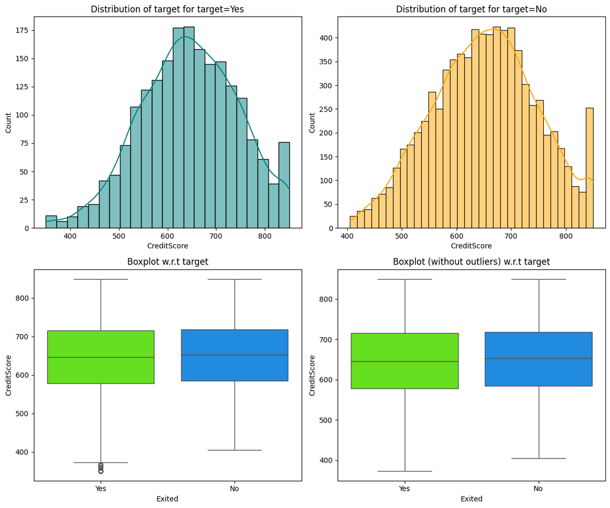

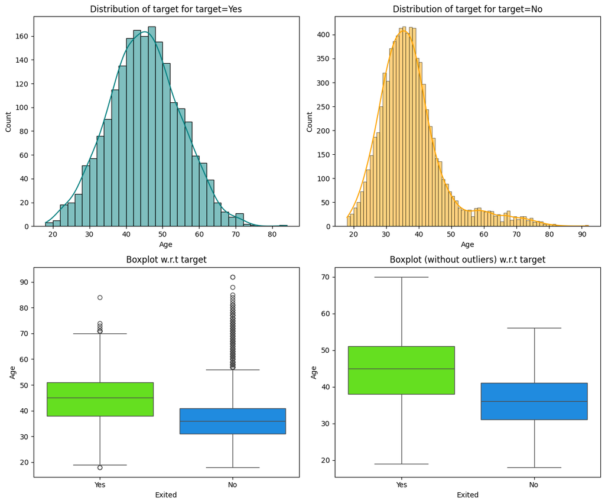

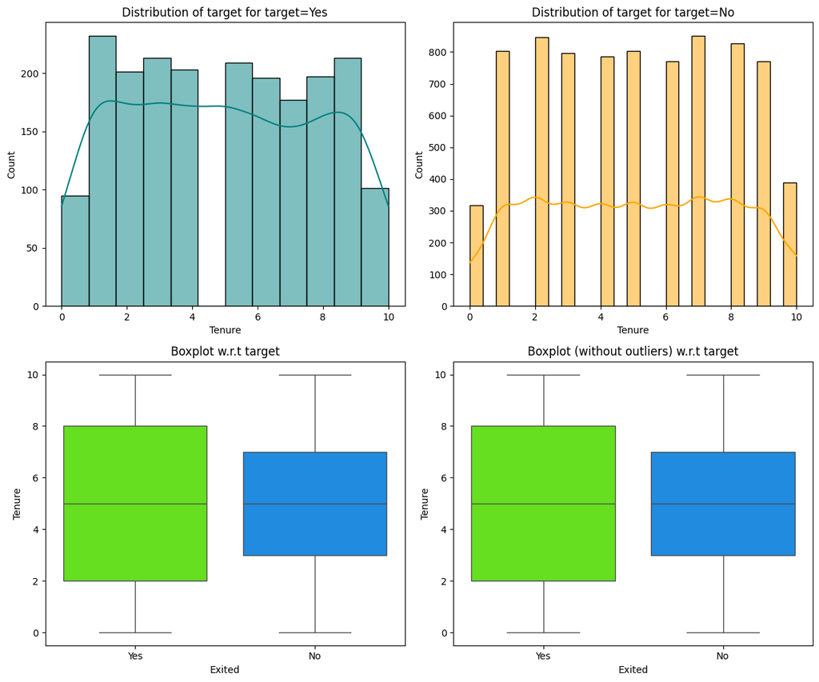

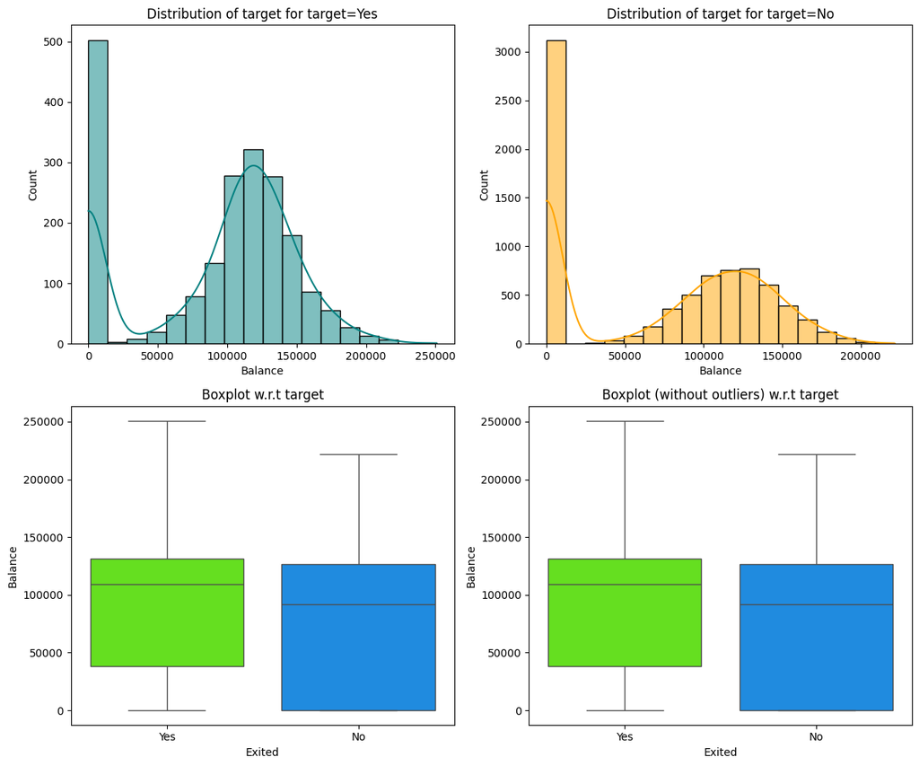

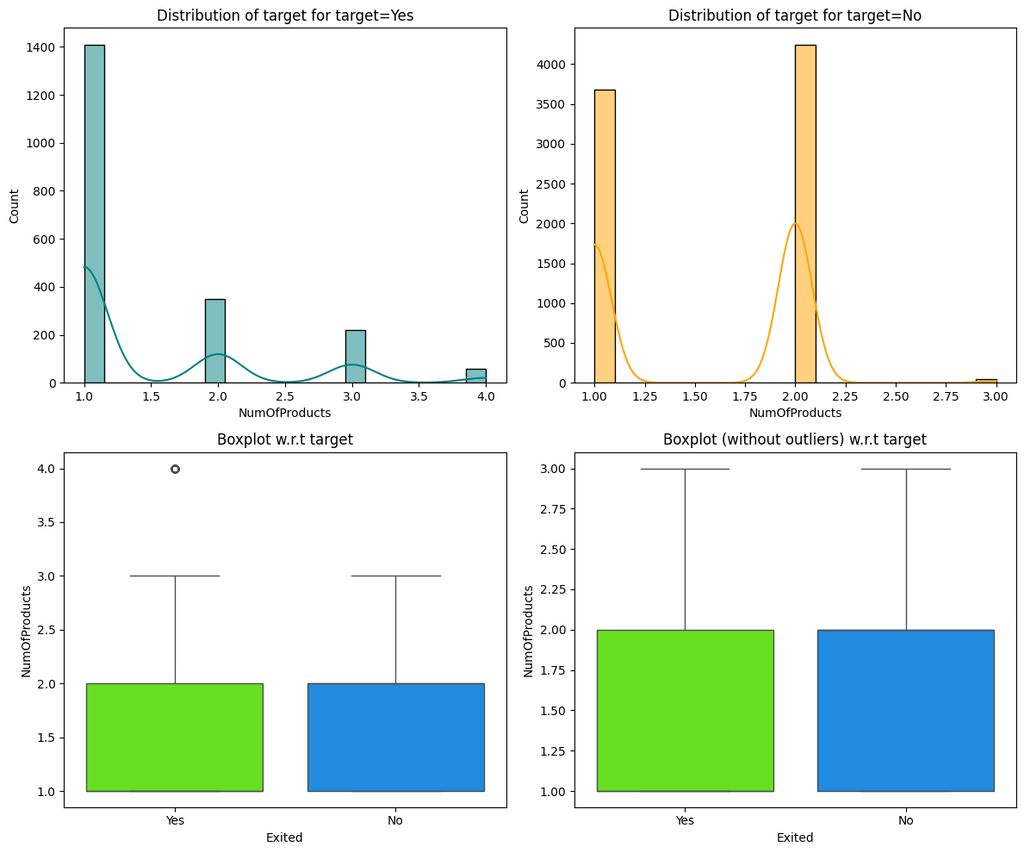

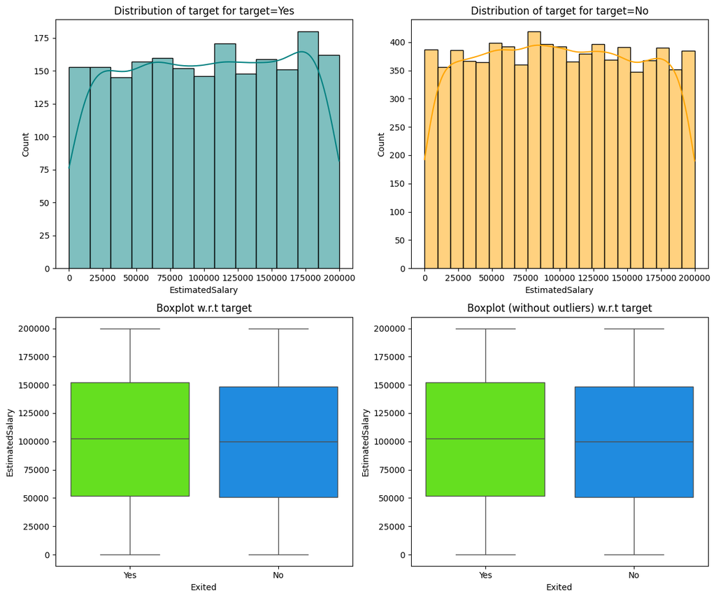

```python
for col in num_cols:
  distribution_plot_wrt_target(df, col, 'Exited')
```

```
Exited       No   Yes    All
Geography
All        7963  2037  10000
Germany    1695   814   2509
France     4204   810   5014
Spain      2064   413   2477
------------------------------------------------------------------------------------------------------------------------
```

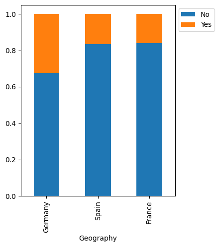

```
Exited    No   Yes    All
Gender
All     7963  2037  10000
Female  3404  1139   4543
Male    4559   898   5457
------------------------------------------------------------------------------------------------------------------------
```

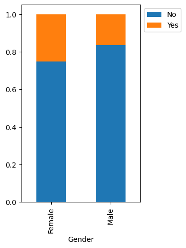

```
Exited       No   Yes    All
HasCrCard
All        7963  2037  10000
Yes        5631  1424   7055
No         2332   613   2945
------------------------------------------------------------------------------------------------------------------------
```

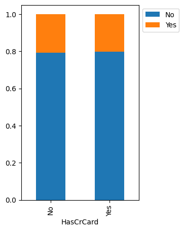

```
Exited            No   Yes    All
IsActiveMember
All             7963  2037  10000
No              3547  1302   4849
Yes             4416   735   5151
------------------------------------------------------------------------------------------------------------------------
```

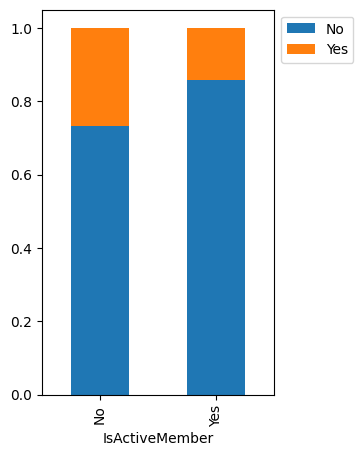

```
Exited    No   Yes    All
Exited
Yes        0  2037   2037
All     7963  2037  10000
No      7963     0   7963
------------------------------------------------------------------------------------------------------------------------
```

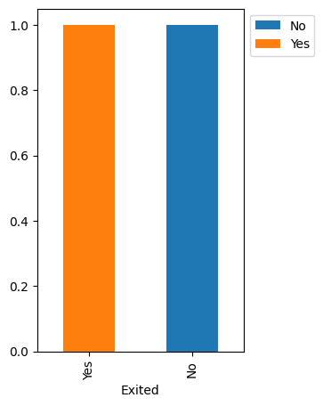

```python
for col in cat_cols:
  stacked_barplot(df, col, 'Exited')
```

## Data Preprocessing

```python
df.info()
```

```
<class 'pandas.core.frame.DataFrame'>
RangeIndex: 10000 entries, 0 to 9999
Data columns (total 11 columns):
 #   Column           Non-Null Count  Dtype
---  ------           --------------  -----
 0   CreditScore      10000 non-null  int64
 1   Geography        10000 non-null  object
 2   Gender           10000 non-null  object
 3   Age              10000 non-null  int64
 4   Tenure           10000 non-null  int64
 5   Balance          10000 non-null  float64
 6   NumOfProducts    10000 non-null  int64
 7   HasCrCard        10000 non-null  object
 8   IsActiveMember   10000 non-null  object
 9   EstimatedSalary  10000 non-null  float64
 10  Exited           10000 non-null  object
dtypes: float64(2), int64(4), object(5)
memory usage: 859.5+ KB
```

```python
X = df.drop('Exited', axis=1)
y = df['Exited']
```

```python
X.info()
```

```
<class 'pandas.core.frame.DataFrame'>
RangeIndex: 10000 entries, 0 to 9999
Data columns (total 10 columns):
 #   Column           Non-Null Count  Dtype
---  ------           --------------  -----
 0   CreditScore      10000 non-null  int64
 1   Geography        10000 non-null  object
 2   Gender           10000 non-null  object
 3   Age              10000 non-null  int64
 4   Tenure           10000 non-null  int64
 5   Balance          10000 non-null  float64
 6   NumOfProducts    10000 non-null  int64
 7   HasCrCard        10000 non-null  object
 8   IsActiveMember   10000 non-null  object
 9   EstimatedSalary  10000 non-null  float64
dtypes: float64(2), int64(4), object(4)
memory usage: 781.4+ KB
```

### Dummy Variable Creation

```python
X = pd.get_dummies(X, drop_first=True)
```

```python
X.info()
```

```
<class 'pandas.core.frame.DataFrame'>
RangeIndex: 10000 entries, 0 to 9999
Data columns (total 11 columns):
 #   Column              Non-Null Count  Dtype
---  ------              --------------  -----
 0   CreditScore         10000 non-null  int64
 1   Age                 10000 non-null  int64
 2   Tenure              10000 non-null  int64
 3   Balance             10000 non-null  float64
 4   NumOfProducts       10000 non-null  int64
 5   EstimatedSalary     10000 non-null  float64
 6   Geography_Germany   10000 non-null  bool
 7   Geography_Spain     10000 non-null  bool
 8   Gender_Male         10000 non-null  bool
 9   HasCrCard_Yes       10000 non-null  bool
 10  IsActiveMember_Yes  10000 non-null  bool
dtypes: bool(5), float64(2), int64(4)
memory usage: 517.7 KB
```

### Encoding the target variable

```python
y = y.replace({'No': 0, 'Yes': 1})
```

### Train-validation-test Split

```python
X_train, X_test, y_train, y_test = train_test_split(X, y, test_size=0.2, random_state=42, stratify=y)
X_train, X_val, y_train, y_val = train_test_split(X_train, y_train, test_size=0.2, random_state=42, stratify=y_train)
```

```python
X_train.head()
```

|  | CreditScore | Age | Tenure | Balance | NumOfProducts | EstimatedSalary | Geography_Germany | Geography_Spain | Gender_Male | HasCrCard_Yes | IsActiveMember_Yes |
| --- | --- | --- | --- | --- | --- | --- | --- | --- | --- | --- | --- |
| 3006 | 747 | 45 | 1 | 114959.12 | 1 | 189362.39 | False | False | False | True | False |
| 5735 | 585 | 44 | 4 | 0.00 | 2 | 101728.46 | False | True | False | False | True |
| 5652 | 691 | 29 | 9 | 0.00 | 2 | 199635.93 | False | False | False | False | False |
| 26 | 756 | 36 | 2 | 136815.64 | 1 | 170041.95 | True | False | True | True | True |
| 3596 | 643 | 36 | 0 | 148159.71 | 1 | 55835.66 | False | False | True | False | False |

### Data Normalization

```python
transformer = StandardScaler()
X_train = transformer.fit_transform(X_train)
X_val = transformer.transform(X_val)
X_test = transformer.transform(X_test)
```

```python
#Printing the shapes.
print(X_train.shape,y_train.shape)
print(X_val.shape,y_val.shape)
print(X_test.shape,y_test.shape)
```

```
(6400, 11) (6400,)
(1600, 11) (1600,)
(2000, 11) (2000,)
```

### Utility Functions

```python
def plot(history, name):
    """
    Function to plot loss/accuracy

    history: an object which stores the metrics and losses.
    name: can be one of Loss or Accuracy
    """
    fig, ax = plt.subplots() #Creating a subplot with figure and axes.
    plt.plot(history.history[name]) #Plotting the train accuracy or train loss
    plt.plot(history.history['val_'+name]) #Plotting the validation accuracy or validation loss

    plt.title('Model ' + name.capitalize()) #Defining the title of the plot.
    plt.ylabel(name.capitalize()) #Capitalizing the first letter.
    plt.xlabel('Epoch') #Defining the label for the x-axis.
    fig.legend(['Train', 'Validation'], loc="outside right upper") #Defining the legend, loc controls the position of the legend.
```

```python
# defining a function to compute different metrics to check performance of a classification model built using statsmodels
def model_performance_classification(
    model, predictors, target, threshold=0.5
):
    """
    Function to compute different metrics to check classification model performance

    model: classifier
    predictors: independent variables
    target: dependent variable
    threshold: threshold for classifying the observation as class 1
    """

    # checking which probabilities are greater than threshold
    pred = model.predict(predictors) > threshold
    # pred_temp = model.predict(predictors) > threshold
    # # rounding off the above values to get classes
    # pred = np.round(pred_temp)

    acc = accuracy_score(target, pred)  # to compute Accuracy
    recall = recall_score(target, pred, average='weighted')  # to compute Recall
    precision = precision_score(target, pred, average='weighted')  # to compute Precision
    f1 = f1_score(target, pred, average='weighted')  # to compute F1-score

    # creating a dataframe of metrics
    df_perf = pd.DataFrame(
        {"Accuracy": acc, "Recall": recall, "Precision": precision, "F1 Score": f1,},
        index=[0],
    )

    return df_perf
```

## Model Building

### Model Evaluation Criterion

**A model can make wrong predictions in the following ways:**

- Predicting a customer will not churn, when he/she churns.
- Predicting a customer will churn when he/she does not churn.

Both are equally important for our case study and model is expected to predict True positives and True negatives. For binary classification problems,

- our accuracy score is important metric as the accuracy gives number of correct predictions to the total predictions.
- Our recall score gives True Positive rate since we have the imbalanced classes, we can check recall scores which measures the True positives to the actual postives. **Improve accuracy and reduce loss i.e need to reduce False Negatives as well as False Positives will be our goal.**

### Neural Network with SGD Optimizer

We'll create a dataframe to store the results from all the models we build

```python
#Defining the columns of the dataframe which are nothing but the hyper parameters and the metrics.
columns = ["Model Used","# hidden layers","# neurons - hidden layer","activation function - hidden layer","# epochs","batch size","train loss","validation loss","train accuracy","validation accuracy","time (secs)"]

#Creating a pandas dataframe.
results = pd.DataFrame(columns=columns)
```

```python
epochs = 100
batch_size = 100
```

```python
tf.keras.backend.clear_session()
model = Sequential()
model.add(Dense(100, activation='relu', input_dim=X_train.shape[1]))
model.add(Dense(100, activation='relu'))
model.add(Dense(1, activation='sigmoid'))

model.summary()
```

```
Model: "sequential"
```

```
┏━━━━━━━━━━━━━━━━━━━━━━━━━━━━━━━━━━━━━━┳━━━━━━━━━━━━━━━━━━━━━━━━━━━━━┳━━━━━━━━━━━━━━━━━┓
┃ Layer (type)                         ┃ Output Shape                ┃         Param # ┃
┡━━━━━━━━━━━━━━━━━━━━━━━━━━━━━━━━━━━━━━╇━━━━━━━━━━━━━━━━━━━━━━━━━━━━━╇━━━━━━━━━━━━━━━━━┩
│ dense (Dense)                        │ (None, 100)                 │           1,200 │
├──────────────────────────────────────┼─────────────────────────────┼─────────────────┤
│ dense_1 (Dense)                      │ (None, 100)                 │          10,100 │
├──────────────────────────────────────┼─────────────────────────────┼─────────────────┤
│ dense_2 (Dense)                      │ (None, 1)                   │             101 │
└──────────────────────────────────────┴─────────────────────────────┴─────────────────┘
```

```
 Total params: 11,401 (44.54 KB)
```

```
 Trainable params: 11,401 (44.54 KB)
```

```
 Non-trainable params: 0 (0.00 B)
```

```python
model.compile(optimizer='sgd', loss='binary_crossentropy', metrics=['accuracy'])
```

```python
start = time.time()
model_history = model.fit(X_train, y_train, epochs=epochs, batch_size=batch_size, validation_data=(X_val, y_val))
end = time.time()
```

```
64/64 ━━━━━━━━━━━━━━━━━━━━ 1s 8ms/step - accuracy: 0.7783 - loss: 0.6003 - val_accuracy: 0.7962 - val_loss: 0.5297
64/64 ━━━━━━━━━━━━━━━━━━━━ 0s 5ms/step - accuracy: 0.7918 - loss: 0.5308 - val_accuracy: 0.7962 - val_loss: 0.5014
64/64 ━━━━━━━━━━━━━━━━━━━━ 1s 5ms/step - accuracy: 0.7918 - loss: 0.5081 - val_accuracy: 0.7962 - val_loss: 0.4885
64/64 ━━━━━━━━━━━━━━━━━━━━ 1s 4ms/step - accuracy: 0.7918 - loss: 0.4965 - val_accuracy: 0.7962 - val_loss: 0.4799
64/64 ━━━━━━━━━━━━━━━━━━━━ 1s 5ms/step - accuracy: 0.7918 - loss: 0.4880 - val_accuracy: 0.7962 - val_loss: 0.4727
64/64 ━━━━━━━━━━━━━━━━━━━━ 1s 4ms/step - accuracy: 0.7918 - loss: 0.4807 - val_accuracy: 0.7962 - val_loss: 0.4665
64/64 ━━━━━━━━━━━━━━━━━━━━ 0s 4ms/step - accuracy: 0.7919 - loss: 0.4743 - val_accuracy: 0.7962 - val_loss: 0.4610
64/64 ━━━━━━━━━━━━━━━━━━━━ 0s 5ms/step - accuracy: 0.7920 - loss: 0.4685 - val_accuracy: 0.7969 - val_loss: 0.4560
64/64 ━━━━━━━━━━━━━━━━━━━━ 0s 3ms/step - accuracy: 0.7928 - loss: 0.4632 - val_accuracy: 0.7962 - val_loss: 0.4516
64/64 ━━━━━━━━━━━━━━━━━━━━ 0s 2ms/step - accuracy: 0.7936 - loss: 0.4584 - val_accuracy: 0.7981 - val_loss: 0.4476
64/64 ━━━━━━━━━━━━━━━━━━━━ 0s 3ms/step - accuracy: 0.7947 - loss: 0.4541 - val_accuracy: 0.7987 - val_loss: 0.4440
64/64 ━━━━━━━━━━━━━━━━━━━━ 0s 3ms/step - accuracy: 0.7970 - loss: 0.4502 - val_accuracy: 0.8031 - val_loss: 0.4408
64/64 ━━━━━━━━━━━━━━━━━━━━ 0s 3ms/step - accuracy: 0.7997 - loss: 0.4466 - val_accuracy: 0.8069 - val_loss: 0.4379
64/64 ━━━━━━━━━━━━━━━━━━━━ 0s 3ms/step - accuracy: 0.8037 - loss: 0.4433 - val_accuracy: 0.8100 - val_loss: 0.4353
64/64 ━━━━━━━━━━━━━━━━━━━━ 0s 3ms/step - accuracy: 0.8050 - loss: 0.4402 - val_accuracy: 0.8106 - val_loss: 0.4330
64/64 ━━━━━━━━━━━━━━━━━━━━ 0s 2ms/step - accuracy: 0.8085 - loss: 0.4375 - val_accuracy: 0.8112 - val_loss: 0.4309
64/64 ━━━━━━━━━━━━━━━━━━━━ 0s 4ms/step - accuracy: 0.8112 - loss: 0.4349 - val_accuracy: 0.8125 - val_loss: 0.4290
64/64 ━━━━━━━━━━━━━━━━━━━━ 0s 2ms/step - accuracy: 0.8114 - loss: 0.4325 - val_accuracy: 0.8150 - val_loss: 0.4272
64/64 ━━━━━━━━━━━━━━━━━━━━ 0s 2ms/step - accuracy: 0.8134 - loss: 0.4302 - val_accuracy: 0.8150 - val_loss: 0.4256
64/64 ━━━━━━━━━━━━━━━━━━━━ 0s 3ms/step - accuracy: 0.8139 - loss: 0.4280 - val_accuracy: 0.8156 - val_loss: 0.4241
64/64 ━━━━━━━━━━━━━━━━━━━━ 0s 3ms/step - accuracy: 0.8161 - loss: 0.4259 - val_accuracy: 0.8188 - val_loss: 0.4226
64/64 ━━━━━━━━━━━━━━━━━━━━ 0s 3ms/step - accuracy: 0.8179 - loss: 0.4240 - val_accuracy: 0.8213 - val_loss: 0.4212
64/64 ━━━━━━━━━━━━━━━━━━━━ 0s 3ms/step - accuracy: 0.8181 - loss: 0.4220 - val_accuracy: 0.8219 - val_loss: 0.4199
64/64 ━━━━━━━━━━━━━━━━━━━━ 0s 3ms/step - accuracy: 0.8186 - loss: 0.4202 - val_accuracy: 0.8238 - val_loss: 0.4186
64/64 ━━━━━━━━━━━━━━━━━━━━ 0s 2ms/step - accuracy: 0.8198 - loss: 0.4183 - val_accuracy: 0.8244 - val_loss: 0.4173
64/64 ━━━━━━━━━━━━━━━━━━━━ 0s 3ms/step - accuracy: 0.8197 - loss: 0.4165 - val_accuracy: 0.8269 - val_loss: 0.4160
64/64 ━━━━━━━━━━━━━━━━━━━━ 0s 2ms/step - accuracy: 0.8215 - loss: 0.4147 - val_accuracy: 0.8288 - val_loss: 0.4148
64/64 ━━━━━━━━━━━━━━━━━━━━ 0s 3ms/step - accuracy: 0.8227 - loss: 0.4130 - val_accuracy: 0.8288 - val_loss: 0.4135
64/64 ━━━━━━━━━━━━━━━━━━━━ 0s 3ms/step - accuracy: 0.8252 - loss: 0.4112 - val_accuracy: 0.8281 - val_loss: 0.4123
64/64 ━━━━━━━━━━━━━━━━━━━━ 0s 3ms/step - accuracy: 0.8263 - loss: 0.4095 - val_accuracy: 0.8288 - val_loss: 0.4111
64/64 ━━━━━━━━━━━━━━━━━━━━ 0s 4ms/step - accuracy: 0.8262 - loss: 0.4078 - val_accuracy: 0.8294 - val_loss: 0.4098
64/64 ━━━━━━━━━━━━━━━━━━━━ 0s 3ms/step - accuracy: 0.8276 - loss: 0.4061 - val_accuracy: 0.8300 - val_loss: 0.4086
64/64 ━━━━━━━━━━━━━━━━━━━━ 0s 2ms/step - accuracy: 0.8301 - loss: 0.4044 - val_accuracy: 0.8306 - val_loss: 0.4074
64/64 ━━━━━━━━━━━━━━━━━━━━ 0s 3ms/step - accuracy: 0.8319 - loss: 0.4027 - val_accuracy: 0.8306 - val_loss: 0.4061
64/64 ━━━━━━━━━━━━━━━━━━━━ 0s 2ms/step - accuracy: 0.8343 - loss: 0.4010 - val_accuracy: 0.8313 - val_loss: 0.4049
64/64 ━━━━━━━━━━━━━━━━━━━━ 0s 3ms/step - accuracy: 0.8346 - loss: 0.3993 - val_accuracy: 0.8325 - val_loss: 0.4036
64/64 ━━━━━━━━━━━━━━━━━━━━ 0s 2ms/step - accuracy: 0.8358 - loss: 0.3976 - val_accuracy: 0.8350 - val_loss: 0.4023
64/64 ━━━━━━━━━━━━━━━━━━━━ 0s 2ms/step - accuracy: 0.8366 - loss: 0.3959 - val_accuracy: 0.8344 - val_loss: 0.4010
64/64 ━━━━━━━━━━━━━━━━━━━━ 0s 3ms/step - accuracy: 0.8374 - loss: 0.3942 - val_accuracy: 0.8350 - val_loss: 0.3997
64/64 ━━━━━━━━━━━━━━━━━━━━ 0s 2ms/step - accuracy: 0.8384 - loss: 0.3925 - val_accuracy: 0.8350 - val_loss: 0.3984
```

[output cut: 45 more lines]

```
64/64 ━━━━━━━━━━━━━━━━━━━━ 0s 4ms/step - accuracy: 0.8634 - loss: 0.3432 - val_accuracy: 0.8537 - val_loss: 0.3595
64/64 ━━━━━━━━━━━━━━━━━━━━ 0s 4ms/step - accuracy: 0.8639 - loss: 0.3428 - val_accuracy: 0.8544 - val_loss: 0.3592
64/64 ━━━━━━━━━━━━━━━━━━━━ 1s 5ms/step - accuracy: 0.8647 - loss: 0.3423 - val_accuracy: 0.8550 - val_loss: 0.3590
64/64 ━━━━━━━━━━━━━━━━━━━━ 1s 5ms/step - accuracy: 0.8648 - loss: 0.3419 - val_accuracy: 0.8550 - val_loss: 0.3587
64/64 ━━━━━━━━━━━━━━━━━━━━ 0s 5ms/step - accuracy: 0.8646 - loss: 0.3415 - val_accuracy: 0.8544 - val_loss: 0.3585
64/64 ━━━━━━━━━━━━━━━━━━━━ 1s 5ms/step - accuracy: 0.8644 - loss: 0.3411 - val_accuracy: 0.8550 - val_loss: 0.3583
64/64 ━━━━━━━━━━━━━━━━━━━━ 0s 4ms/step - accuracy: 0.8644 - loss: 0.3407 - val_accuracy: 0.8556 - val_loss: 0.3581
64/64 ━━━━━━━━━━━━━━━━━━━━ 0s 4ms/step - accuracy: 0.8639 - loss: 0.3403 - val_accuracy: 0.8562 - val_loss: 0.3578
64/64 ━━━━━━━━━━━━━━━━━━━━ 1s 5ms/step - accuracy: 0.8644 - loss: 0.3400 - val_accuracy: 0.8569 - val_loss: 0.3576
64/64 ━━━━━━━━━━━━━━━━━━━━ 0s 3ms/step - accuracy: 0.8644 - loss: 0.3396 - val_accuracy: 0.8569 - val_loss: 0.3574
64/64 ━━━━━━━━━━━━━━━━━━━━ 0s 3ms/step - accuracy: 0.8644 - loss: 0.3393 - val_accuracy: 0.8569 - val_loss: 0.3572
64/64 ━━━━━━━━━━━━━━━━━━━━ 0s 3ms/step - accuracy: 0.8645 - loss: 0.3389 - val_accuracy: 0.8575 - val_loss: 0.3570
64/64 ━━━━━━━━━━━━━━━━━━━━ 0s 3ms/step - accuracy: 0.8645 - loss: 0.3386 - val_accuracy: 0.8569 - val_loss: 0.3568
64/64 ━━━━━━━━━━━━━━━━━━━━ 0s 3ms/step - accuracy: 0.8645 - loss: 0.3383 - val_accuracy: 0.8569 - val_loss: 0.3567
64/64 ━━━━━━━━━━━━━━━━━━━━ 0s 3ms/step - accuracy: 0.8643 - loss: 0.3380 - val_accuracy: 0.8569 - val_loss: 0.3565
```

```python
print("Time taken in seconds ",end-start)
```

```
Time taken in seconds  34.71156311035156
```

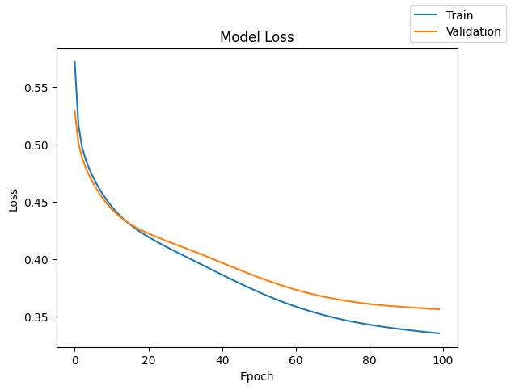

```python
plot(model_history, 'loss')
```

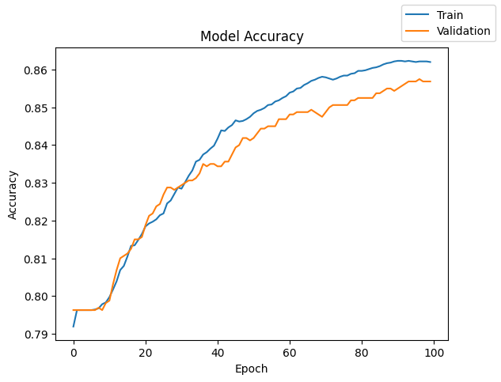

```python
plot(model_history, 'accuracy')
```

```python
model_0_train_perf = model_performance_classification(model, X_train, y_train)
model_0_train_perf
```

```
200/200 ━━━━━━━━━━━━━━━━━━━━ 0s 2ms/step
```

|  | Accuracy | Recall | Precision | F1 Score |
| --- | --- | --- | --- | --- |
| 0 | 0.862344 | 0.862344 | 0.853932 | 0.848227 |

```python
model_0_valid_perf = model_performance_classification(model, X_val, y_val)
model_0_valid_perf
```

```
50/50 ━━━━━━━━━━━━━━━━━━━━ 0s 1ms/step
```

|  | Accuracy | Recall | Precision | F1 Score |
| --- | --- | --- | --- | --- |
| 0 | 0.856875 | 0.856875 | 0.84893 | 0.83866 |

```python
results.loc[0] = ["NN with SGD",2,'-','-',50,100,model_history.history["loss"][-1],model_history.history["val_loss"][-1],model_history.history["accuracy"][-1],model_history.history["val_accuracy"][-1],round(end-start,2)]

results
```

[output not shown]

### Model Neural Network with SGD and Momentum

```python
epochs = 50
batch_size = 32
```

```python
model = Sequential()
model.add(Dense(100, activation='relu', input_dim=X_train.shape[1]))
model.add(Dense(100, activation='relu'))
model.add(Dense(1, activation='sigmoid'))

model.summary()
```

```
Model: "sequential_13"
```

```
┏━━━━━━━━━━━━━━━━━━━━━━━━━━━━━━━━━━━━━━┳━━━━━━━━━━━━━━━━━━━━━━━━━━━━━┳━━━━━━━━━━━━━━━━━┓
┃ Layer (type)                         ┃ Output Shape                ┃         Param # ┃
┡━━━━━━━━━━━━━━━━━━━━━━━━━━━━━━━━━━━━━━╇━━━━━━━━━━━━━━━━━━━━━━━━━━━━━╇━━━━━━━━━━━━━━━━━┩
│ dense_33 (Dense)                     │ (None, 100)                 │           1,200 │
├──────────────────────────────────────┼─────────────────────────────┼─────────────────┤
│ dense_34 (Dense)                     │ (None, 100)                 │          10,100 │
├──────────────────────────────────────┼─────────────────────────────┼─────────────────┤
│ dense_35 (Dense)                     │ (None, 1)                   │             101 │
└──────────────────────────────────────┴─────────────────────────────┴─────────────────┘
```

```
 Total params: 11,401 (44.54 KB)
```

```
 Trainable params: 11,401 (44.54 KB)
```

```
 Non-trainable params: 0 (0.00 B)
```

```python
optimizer = tf.keras.optimizers.SGD(momentum=0.9)
model.compile(optimizer=optimizer, loss='binary_crossentropy', metrics=['accuracy'])
```

```python
start = time.time()
model_history = model.fit(X_train, y_train, epochs=epochs, batch_size=batch_size, validation_data=(X_val, y_val))
end = time.time()
```

```
200/200 ━━━━━━━━━━━━━━━━━━━━ 2s 5ms/step - accuracy: 0.7713 - loss: 0.5026 - val_accuracy: 0.8344 - val_loss: 0.4084
200/200 ━━━━━━━━━━━━━━━━━━━━ 1s 3ms/step - accuracy: 0.8322 - loss: 0.3962 - val_accuracy: 0.8506 - val_loss: 0.3715
200/200 ━━━━━━━━━━━━━━━━━━━━ 1s 4ms/step - accuracy: 0.8480 - loss: 0.3621 - val_accuracy: 0.8537 - val_loss: 0.3594
200/200 ━━━━━━━━━━━━━━━━━━━━ 1s 3ms/step - accuracy: 0.8547 - loss: 0.3503 - val_accuracy: 0.8556 - val_loss: 0.3564
200/200 ━━━━━━━━━━━━━━━━━━━━ 1s 2ms/step - accuracy: 0.8550 - loss: 0.3445 - val_accuracy: 0.8550 - val_loss: 0.3545
200/200 ━━━━━━━━━━━━━━━━━━━━ 0s 2ms/step - accuracy: 0.8581 - loss: 0.3404 - val_accuracy: 0.8587 - val_loss: 0.3532
200/200 ━━━━━━━━━━━━━━━━━━━━ 1s 2ms/step - accuracy: 0.8600 - loss: 0.3368 - val_accuracy: 0.8594 - val_loss: 0.3522
200/200 ━━━━━━━━━━━━━━━━━━━━ 1s 2ms/step - accuracy: 0.8593 - loss: 0.3340 - val_accuracy: 0.8612 - val_loss: 0.3515
200/200 ━━━━━━━━━━━━━━━━━━━━ 0s 2ms/step - accuracy: 0.8617 - loss: 0.3312 - val_accuracy: 0.8619 - val_loss: 0.3508
200/200 ━━━━━━━━━━━━━━━━━━━━ 0s 2ms/step - accuracy: 0.8629 - loss: 0.3285 - val_accuracy: 0.8612 - val_loss: 0.3503
200/200 ━━━━━━━━━━━━━━━━━━━━ 1s 2ms/step - accuracy: 0.8631 - loss: 0.3262 - val_accuracy: 0.8625 - val_loss: 0.3499
200/200 ━━━━━━━━━━━━━━━━━━━━ 1s 2ms/step - accuracy: 0.8639 - loss: 0.3237 - val_accuracy: 0.8581 - val_loss: 0.3499
200/200 ━━━━━━━━━━━━━━━━━━━━ 1s 3ms/step - accuracy: 0.8653 - loss: 0.3214 - val_accuracy: 0.8581 - val_loss: 0.3500
200/200 ━━━━━━━━━━━━━━━━━━━━ 0s 2ms/step - accuracy: 0.8670 - loss: 0.3191 - val_accuracy: 0.8575 - val_loss: 0.3501
200/200 ━━━━━━━━━━━━━━━━━━━━ 1s 2ms/step - accuracy: 0.8667 - loss: 0.3167 - val_accuracy: 0.8569 - val_loss: 0.3506
200/200 ━━━━━━━━━━━━━━━━━━━━ 1s 2ms/step - accuracy: 0.8655 - loss: 0.3145 - val_accuracy: 0.8550 - val_loss: 0.3509
200/200 ━━━━━━━━━━━━━━━━━━━━ 0s 2ms/step - accuracy: 0.8659 - loss: 0.3124 - val_accuracy: 0.8537 - val_loss: 0.3513
200/200 ━━━━━━━━━━━━━━━━━━━━ 1s 3ms/step - accuracy: 0.8677 - loss: 0.3104 - val_accuracy: 0.8537 - val_loss: 0.3519
200/200 ━━━━━━━━━━━━━━━━━━━━ 1s 2ms/step - accuracy: 0.8695 - loss: 0.3085 - val_accuracy: 0.8531 - val_loss: 0.3526
200/200 ━━━━━━━━━━━━━━━━━━━━ 1s 2ms/step - accuracy: 0.8696 - loss: 0.3068 - val_accuracy: 0.8537 - val_loss: 0.3531
200/200 ━━━━━━━━━━━━━━━━━━━━ 1s 3ms/step - accuracy: 0.8695 - loss: 0.3050 - val_accuracy: 0.8525 - val_loss: 0.3537
200/200 ━━━━━━━━━━━━━━━━━━━━ 1s 4ms/step - accuracy: 0.8717 - loss: 0.3031 - val_accuracy: 0.8525 - val_loss: 0.3540
200/200 ━━━━━━━━━━━━━━━━━━━━ 1s 3ms/step - accuracy: 0.8719 - loss: 0.3014 - val_accuracy: 0.8525 - val_loss: 0.3550
200/200 ━━━━━━━━━━━━━━━━━━━━ 1s 4ms/step - accuracy: 0.8735 - loss: 0.2996 - val_accuracy: 0.8525 - val_loss: 0.3556
200/200 ━━━━━━━━━━━━━━━━━━━━ 1s 2ms/step - accuracy: 0.8738 - loss: 0.2979 - val_accuracy: 0.8525 - val_loss: 0.3563
200/200 ━━━━━━━━━━━━━━━━━━━━ 1s 2ms/step - accuracy: 0.8743 - loss: 0.2962 - val_accuracy: 0.8537 - val_loss: 0.3575
200/200 ━━━━━━━━━━━━━━━━━━━━ 1s 3ms/step - accuracy: 0.8754 - loss: 0.2944 - val_accuracy: 0.8550 - val_loss: 0.3586
200/200 ━━━━━━━━━━━━━━━━━━━━ 1s 2ms/step - accuracy: 0.8764 - loss: 0.2924 - val_accuracy: 0.8550 - val_loss: 0.3604
200/200 ━━━━━━━━━━━━━━━━━━━━ 0s 2ms/step - accuracy: 0.8764 - loss: 0.2907 - val_accuracy: 0.8544 - val_loss: 0.3617
200/200 ━━━━━━━━━━━━━━━━━━━━ 1s 3ms/step - accuracy: 0.8756 - loss: 0.2889 - val_accuracy: 0.8556 - val_loss: 0.3628
200/200 ━━━━━━━━━━━━━━━━━━━━ 1s 2ms/step - accuracy: 0.8755 - loss: 0.2872 - val_accuracy: 0.8544 - val_loss: 0.3645
200/200 ━━━━━━━━━━━━━━━━━━━━ 1s 2ms/step - accuracy: 0.8752 - loss: 0.2854 - val_accuracy: 0.8556 - val_loss: 0.3661
200/200 ━━━━━━━━━━━━━━━━━━━━ 1s 3ms/step - accuracy: 0.8769 - loss: 0.2837 - val_accuracy: 0.8537 - val_loss: 0.3675
200/200 ━━━━━━━━━━━━━━━━━━━━ 1s 2ms/step - accuracy: 0.8773 - loss: 0.2819 - val_accuracy: 0.8531 - val_loss: 0.3689
200/200 ━━━━━━━━━━━━━━━━━━━━ 1s 2ms/step - accuracy: 0.8773 - loss: 0.2801 - val_accuracy: 0.8519 - val_loss: 0.3699
200/200 ━━━━━━━━━━━━━━━━━━━━ 1s 3ms/step - accuracy: 0.8769 - loss: 0.2786 - val_accuracy: 0.8544 - val_loss: 0.3720
200/200 ━━━━━━━━━━━━━━━━━━━━ 0s 2ms/step - accuracy: 0.8781 - loss: 0.2769 - val_accuracy: 0.8531 - val_loss: 0.3736
200/200 ━━━━━━━━━━━━━━━━━━━━ 0s 2ms/step - accuracy: 0.8783 - loss: 0.2750 - val_accuracy: 0.8525 - val_loss: 0.3756
200/200 ━━━━━━━━━━━━━━━━━━━━ 1s 2ms/step - accuracy: 0.8773 - loss: 0.2733 - val_accuracy: 0.8537 - val_loss: 0.3774
200/200 ━━━━━━━━━━━━━━━━━━━━ 1s 2ms/step - accuracy: 0.8769 - loss: 0.2717 - val_accuracy: 0.8531 - val_loss: 0.3789
200/200 ━━━━━━━━━━━━━━━━━━━━ 1s 2ms/step - accuracy: 0.8786 - loss: 0.2699 - val_accuracy: 0.8537 - val_loss: 0.3812
200/200 ━━━━━━━━━━━━━━━━━━━━ 1s 4ms/step - accuracy: 0.8810 - loss: 0.2682 - val_accuracy: 0.8512 - val_loss: 0.3821
200/200 ━━━━━━━━━━━━━━━━━━━━ 1s 3ms/step - accuracy: 0.8828 - loss: 0.2664 - val_accuracy: 0.8537 - val_loss: 0.3839
200/200 ━━━━━━━━━━━━━━━━━━━━ 1s 4ms/step - accuracy: 0.8835 - loss: 0.2649 - val_accuracy: 0.8544 - val_loss: 0.3861
200/200 ━━━━━━━━━━━━━━━━━━━━ 1s 2ms/step - accuracy: 0.8845 - loss: 0.2631 - val_accuracy: 0.8537 - val_loss: 0.3875
200/200 ━━━━━━━━━━━━━━━━━━━━ 1s 2ms/step - accuracy: 0.8840 - loss: 0.2612 - val_accuracy: 0.8531 - val_loss: 0.3897
200/200 ━━━━━━━━━━━━━━━━━━━━ 1s 2ms/step - accuracy: 0.8854 - loss: 0.2596 - val_accuracy: 0.8519 - val_loss: 0.3921
200/200 ━━━━━━━━━━━━━━━━━━━━ 1s 2ms/step - accuracy: 0.8876 - loss: 0.2580 - val_accuracy: 0.8512 - val_loss: 0.3933
200/200 ━━━━━━━━━━━━━━━━━━━━ 1s 2ms/step - accuracy: 0.8894 - loss: 0.2559 - val_accuracy: 0.8512 - val_loss: 0.3952
200/200 ━━━━━━━━━━━━━━━━━━━━ 1s 2ms/step - accuracy: 0.8896 - loss: 0.2543 - val_accuracy: 0.8506 - val_loss: 0.3975
```

```python
print("Time taken in seconds ",end-start)
```

```
Time taken in seconds  36.29561972618103
```

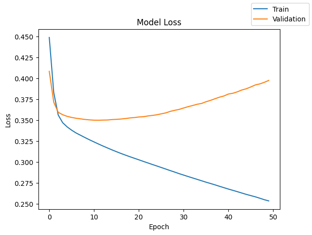

```python
plot(model_history, 'loss')
```

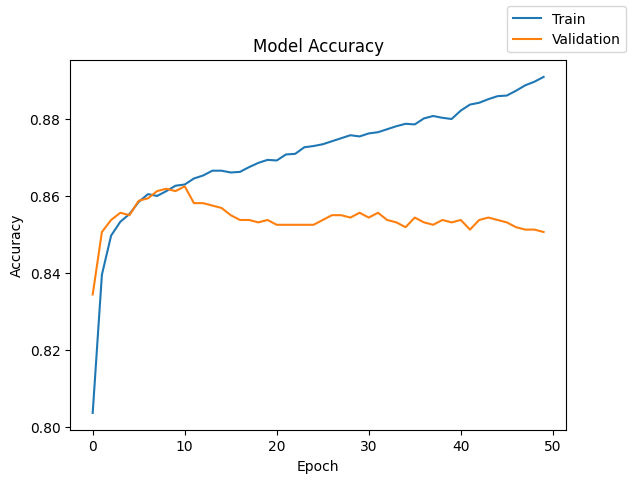

```python
plot(model_history, 'accuracy')
```

```python
model_1_train_perf = model_performance_classification(model, X_train, y_train)
model_1_train_perf
```

```
200/200 ━━━━━━━━━━━━━━━━━━━━ 1s 2ms/step
```

|  | Accuracy | Recall | Precision | F1 Score |
| --- | --- | --- | --- | --- |
| 0 | 0.899219 | 0.899219 | 0.895241 | 0.895512 |

```python
model_1_valid_perf = model_performance_classification(model, X_val, y_val)
model_1_valid_perf
```

```
50/50 ━━━━━━━━━━━━━━━━━━━━ 0s 2ms/step
```

|  | Accuracy | Recall | Precision | F1 Score |
| --- | --- | --- | --- | --- |
| 0 | 0.850625 | 0.850625 | 0.840767 | 0.843052 |

```python
results.loc[1] = ["NN with SGD and Momentum",2,'100','relu',50,32,model_history.history["loss"][-1],model_history.history["val_loss"][-1],model_history.history["accuracy"][-1],model_history.history["val_accuracy"][-1],round(end-start,2)]
results[0:2]
```

[output not shown]

## Model Performance Improvement

```python
epochs = 100
batch_size = 32
```

### Neural Network with Adam Optimizer

```python
model = Sequential()
model.add(Dense(100, activation='relu', input_dim=X_train.shape[1]))
model.add(Dense(100, activation='relu'))
model.add(Dense(1, activation='sigmoid'))

model.summary()
```

```
Model: "sequential_2"
```

```
┏━━━━━━━━━━━━━━━━━━━━━━━━━━━━━━━━━━━━━━┳━━━━━━━━━━━━━━━━━━━━━━━━━━━━━┳━━━━━━━━━━━━━━━━━┓
┃ Layer (type)                         ┃ Output Shape                ┃         Param # ┃
┡━━━━━━━━━━━━━━━━━━━━━━━━━━━━━━━━━━━━━━╇━━━━━━━━━━━━━━━━━━━━━━━━━━━━━╇━━━━━━━━━━━━━━━━━┩
│ dense_6 (Dense)                      │ (None, 100)                 │           1,200 │
├──────────────────────────────────────┼─────────────────────────────┼─────────────────┤
│ dense_7 (Dense)                      │ (None, 100)                 │          10,100 │
├──────────────────────────────────────┼─────────────────────────────┼─────────────────┤
│ dense_8 (Dense)                      │ (None, 1)                   │             101 │
└──────────────────────────────────────┴─────────────────────────────┴─────────────────┘
```

```
 Total params: 11,401 (44.54 KB)
```

```
 Trainable params: 11,401 (44.54 KB)
```

```
 Non-trainable params: 0 (0.00 B)
```

```python
model.compile(optimizer='adam', loss='binary_crossentropy', metrics=['accuracy'])
```

```python
start = time.time()
model_history = model.fit(X_train, y_train, epochs=epochs, batch_size=batch_size, validation_data=(X_val, y_val))
end = time.time()
```

```
200/200 ━━━━━━━━━━━━━━━━━━━━ 3s 5ms/step - accuracy: 0.7840 - loss: 0.4881 - val_accuracy: 0.8394 - val_loss: 0.3944
200/200 ━━━━━━━━━━━━━━━━━━━━ 1s 4ms/step - accuracy: 0.8426 - loss: 0.3799 - val_accuracy: 0.8487 - val_loss: 0.3630
200/200 ━━━━━━━━━━━━━━━━━━━━ 0s 2ms/step - accuracy: 0.8547 - loss: 0.3525 - val_accuracy: 0.8575 - val_loss: 0.3553
200/200 ━━━━━━━━━━━━━━━━━━━━ 1s 2ms/step - accuracy: 0.8554 - loss: 0.3436 - val_accuracy: 0.8556 - val_loss: 0.3530
200/200 ━━━━━━━━━━━━━━━━━━━━ 1s 2ms/step - accuracy: 0.8569 - loss: 0.3382 - val_accuracy: 0.8550 - val_loss: 0.3520
200/200 ━━━━━━━━━━━━━━━━━━━━ 1s 2ms/step - accuracy: 0.8573 - loss: 0.3340 - val_accuracy: 0.8562 - val_loss: 0.3517
200/200 ━━━━━━━━━━━━━━━━━━━━ 1s 2ms/step - accuracy: 0.8591 - loss: 0.3303 - val_accuracy: 0.8550 - val_loss: 0.3517
200/200 ━━━━━━━━━━━━━━━━━━━━ 1s 2ms/step - accuracy: 0.8628 - loss: 0.3270 - val_accuracy: 0.8562 - val_loss: 0.3513
200/200 ━━━━━━━━━━━━━━━━━━━━ 1s 2ms/step - accuracy: 0.8649 - loss: 0.3240 - val_accuracy: 0.8562 - val_loss: 0.3513
200/200 ━━━━━━━━━━━━━━━━━━━━ 0s 2ms/step - accuracy: 0.8656 - loss: 0.3211 - val_accuracy: 0.8537 - val_loss: 0.3518
200/200 ━━━━━━━━━━━━━━━━━━━━ 1s 2ms/step - accuracy: 0.8651 - loss: 0.3183 - val_accuracy: 0.8531 - val_loss: 0.3523
200/200 ━━━━━━━━━━━━━━━━━━━━ 1s 2ms/step - accuracy: 0.8659 - loss: 0.3157 - val_accuracy: 0.8531 - val_loss: 0.3529
200/200 ━━━━━━━━━━━━━━━━━━━━ 1s 2ms/step - accuracy: 0.8662 - loss: 0.3133 - val_accuracy: 0.8525 - val_loss: 0.3536
200/200 ━━━━━━━━━━━━━━━━━━━━ 1s 2ms/step - accuracy: 0.8677 - loss: 0.3110 - val_accuracy: 0.8519 - val_loss: 0.3543
200/200 ━━━━━━━━━━━━━━━━━━━━ 1s 2ms/step - accuracy: 0.8670 - loss: 0.3088 - val_accuracy: 0.8525 - val_loss: 0.3554
200/200 ━━━━━━━━━━━━━━━━━━━━ 1s 2ms/step - accuracy: 0.8689 - loss: 0.3064 - val_accuracy: 0.8525 - val_loss: 0.3563
200/200 ━━━━━━━━━━━━━━━━━━━━ 0s 2ms/step - accuracy: 0.8687 - loss: 0.3042 - val_accuracy: 0.8512 - val_loss: 0.3573
200/200 ━━━━━━━━━━━━━━━━━━━━ 1s 2ms/step - accuracy: 0.8697 - loss: 0.3018 - val_accuracy: 0.8537 - val_loss: 0.3583
200/200 ━━━━━━━━━━━━━━━━━━━━ 1s 3ms/step - accuracy: 0.8701 - loss: 0.2998 - val_accuracy: 0.8556 - val_loss: 0.3592
200/200 ━━━━━━━━━━━━━━━━━━━━ 1s 4ms/step - accuracy: 0.8719 - loss: 0.2975 - val_accuracy: 0.8550 - val_loss: 0.3598
200/200 ━━━━━━━━━━━━━━━━━━━━ 1s 4ms/step - accuracy: 0.8737 - loss: 0.2953 - val_accuracy: 0.8550 - val_loss: 0.3613
200/200 ━━━━━━━━━━━━━━━━━━━━ 1s 4ms/step - accuracy: 0.8734 - loss: 0.2930 - val_accuracy: 0.8544 - val_loss: 0.3627
200/200 ━━━━━━━━━━━━━━━━━━━━ 1s 4ms/step - accuracy: 0.8748 - loss: 0.2907 - val_accuracy: 0.8531 - val_loss: 0.3641
200/200 ━━━━━━━━━━━━━━━━━━━━ 1s 2ms/step - accuracy: 0.8753 - loss: 0.2885 - val_accuracy: 0.8531 - val_loss: 0.3655
200/200 ━━━━━━━━━━━━━━━━━━━━ 1s 3ms/step - accuracy: 0.8760 - loss: 0.2864 - val_accuracy: 0.8519 - val_loss: 0.3673
200/200 ━━━━━━━━━━━━━━━━━━━━ 0s 2ms/step - accuracy: 0.8768 - loss: 0.2843 - val_accuracy: 0.8519 - val_loss: 0.3688
200/200 ━━━━━━━━━━━━━━━━━━━━ 1s 2ms/step - accuracy: 0.8784 - loss: 0.2819 - val_accuracy: 0.8525 - val_loss: 0.3701
200/200 ━━━━━━━━━━━━━━━━━━━━ 1s 2ms/step - accuracy: 0.8790 - loss: 0.2798 - val_accuracy: 0.8525 - val_loss: 0.3717
200/200 ━━━━━━━━━━━━━━━━━━━━ 1s 2ms/step - accuracy: 0.8801 - loss: 0.2777 - val_accuracy: 0.8519 - val_loss: 0.3730
200/200 ━━━━━━━━━━━━━━━━━━━━ 1s 2ms/step - accuracy: 0.8801 - loss: 0.2757 - val_accuracy: 0.8519 - val_loss: 0.3746
200/200 ━━━━━━━━━━━━━━━━━━━━ 0s 2ms/step - accuracy: 0.8807 - loss: 0.2735 - val_accuracy: 0.8512 - val_loss: 0.3760
200/200 ━━━━━━━━━━━━━━━━━━━━ 1s 3ms/step - accuracy: 0.8819 - loss: 0.2716 - val_accuracy: 0.8519 - val_loss: 0.3778
200/200 ━━━━━━━━━━━━━━━━━━━━ 1s 3ms/step - accuracy: 0.8830 - loss: 0.2697 - val_accuracy: 0.8525 - val_loss: 0.3799
200/200 ━━━━━━━━━━━━━━━━━━━━ 1s 2ms/step - accuracy: 0.8826 - loss: 0.2679 - val_accuracy: 0.8531 - val_loss: 0.3815
200/200 ━━━━━━━━━━━━━━━━━━━━ 0s 2ms/step - accuracy: 0.8832 - loss: 0.2658 - val_accuracy: 0.8544 - val_loss: 0.3837
200/200 ━━━━━━━━━━━━━━━━━━━━ 1s 2ms/step - accuracy: 0.8845 - loss: 0.2639 - val_accuracy: 0.8525 - val_loss: 0.3849
200/200 ━━━━━━━━━━━━━━━━━━━━ 1s 2ms/step - accuracy: 0.8848 - loss: 0.2618 - val_accuracy: 0.8531 - val_loss: 0.3864
200/200 ━━━━━━━━━━━━━━━━━━━━ 1s 2ms/step - accuracy: 0.8878 - loss: 0.2598 - val_accuracy: 0.8512 - val_loss: 0.3884
200/200 ━━━━━━━━━━━━━━━━━━━━ 1s 2ms/step - accuracy: 0.8890 - loss: 0.2576 - val_accuracy: 0.8512 - val_loss: 0.3897
200/200 ━━━━━━━━━━━━━━━━━━━━ 1s 3ms/step - accuracy: 0.8895 - loss: 0.2557 - val_accuracy: 0.8544 - val_loss: 0.3918
```

[output cut: 45 more lines]

```
200/200 ━━━━━━━━━━━━━━━━━━━━ 1s 2ms/step - accuracy: 0.9291 - loss: 0.1703 - val_accuracy: 0.8425 - val_loss: 0.5145
200/200 ━━━━━━━━━━━━━━━━━━━━ 1s 3ms/step - accuracy: 0.9300 - loss: 0.1682 - val_accuracy: 0.8413 - val_loss: 0.5194
200/200 ━━━━━━━━━━━━━━━━━━━━ 1s 2ms/step - accuracy: 0.9312 - loss: 0.1670 - val_accuracy: 0.8406 - val_loss: 0.5217
200/200 ━━━━━━━━━━━━━━━━━━━━ 1s 2ms/step - accuracy: 0.9324 - loss: 0.1647 - val_accuracy: 0.8400 - val_loss: 0.5255
200/200 ━━━━━━━━━━━━━━━━━━━━ 1s 2ms/step - accuracy: 0.9333 - loss: 0.1633 - val_accuracy: 0.8381 - val_loss: 0.5297
200/200 ━━━━━━━━━━━━━━━━━━━━ 1s 2ms/step - accuracy: 0.9346 - loss: 0.1611 - val_accuracy: 0.8394 - val_loss: 0.5323
200/200 ━━━━━━━━━━━━━━━━━━━━ 1s 2ms/step - accuracy: 0.9365 - loss: 0.1600 - val_accuracy: 0.8381 - val_loss: 0.5371
200/200 ━━━━━━━━━━━━━━━━━━━━ 1s 3ms/step - accuracy: 0.9380 - loss: 0.1586 - val_accuracy: 0.8388 - val_loss: 0.5433
200/200 ━━━━━━━━━━━━━━━━━━━━ 1s 2ms/step - accuracy: 0.9369 - loss: 0.1570 - val_accuracy: 0.8394 - val_loss: 0.5457
200/200 ━━━━━━━━━━━━━━━━━━━━ 1s 3ms/step - accuracy: 0.9394 - loss: 0.1549 - val_accuracy: 0.8388 - val_loss: 0.5498
200/200 ━━━━━━━━━━━━━━━━━━━━ 1s 2ms/step - accuracy: 0.9423 - loss: 0.1527 - val_accuracy: 0.8388 - val_loss: 0.5552
200/200 ━━━━━━━━━━━━━━━━━━━━ 1s 3ms/step - accuracy: 0.9416 - loss: 0.1519 - val_accuracy: 0.8375 - val_loss: 0.5588
200/200 ━━━━━━━━━━━━━━━━━━━━ 1s 2ms/step - accuracy: 0.9429 - loss: 0.1502 - val_accuracy: 0.8381 - val_loss: 0.5644
200/200 ━━━━━━━━━━━━━━━━━━━━ 1s 2ms/step - accuracy: 0.9434 - loss: 0.1483 - val_accuracy: 0.8406 - val_loss: 0.5677
200/200 ━━━━━━━━━━━━━━━━━━━━ 1s 2ms/step - accuracy: 0.9448 - loss: 0.1469 - val_accuracy: 0.8388 - val_loss: 0.5732
```

```python
print("Time taken in seconds ",end-start)
```

```
Time taken in seconds  69.14844632148743
```

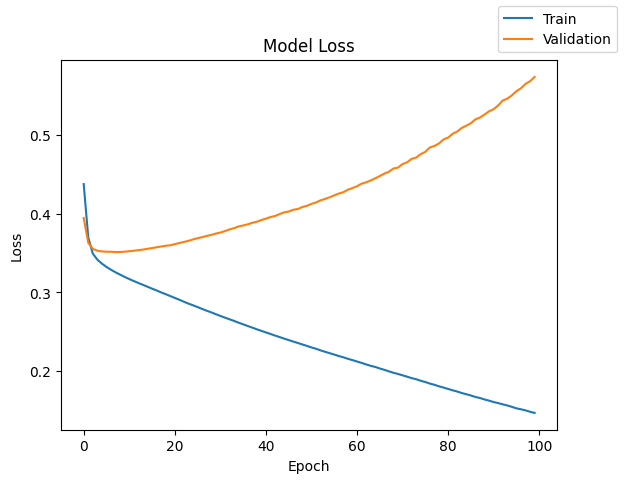

```python
plot(model_history, 'loss')
```

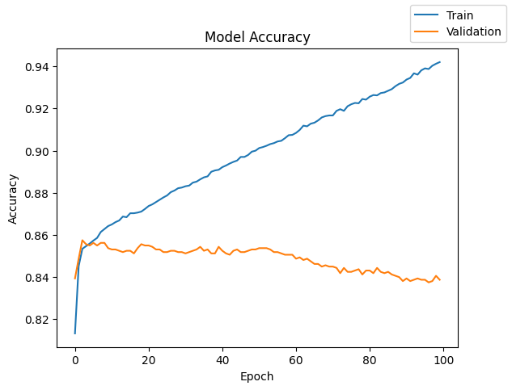

```python
plot(model_history, 'accuracy')
```

```python
model_2_train_perf = model_performance_classification(model, X_train, y_train)
model_2_train_perf
```

```
200/200 ━━━━━━━━━━━━━━━━━━━━ 0s 2ms/step
```

|  | Accuracy | Recall | Precision | F1 Score |
| --- | --- | --- | --- | --- |
| 0 | 0.931406 | 0.931406 | 0.929915 | 0.929206 |

```python
model_2_valid_perf = model_performance_classification(model, X_val, y_val)
model_2_valid_perf
```

```
50/50 ━━━━━━━━━━━━━━━━━━━━ 0s 2ms/step
```

|  | Accuracy | Recall | Precision | F1 Score |
| --- | --- | --- | --- | --- |
| 0 | 0.83875 | 0.83875 | 0.826093 | 0.828862 |

```python
results.loc[2] = ["NN with Adam", 2,'100','relu',100,32,model_history.history["loss"][-1],model_history.history["val_loss"][-1],model_history.history["accuracy"][-1],model_history.history["val_accuracy"][-1],round(end-start,2)]
results[0:3]
```

[output not shown]

### Neural Network with Adam Optimizer and Dropout

```python
model = Sequential()
model.add(Dense(100, activation='relu', input_dim=X_train.shape[1]))
model.add(Dropout(0.2))
model.add(Dense(100, activation='tanh'))
model.add(Dropout(0.2))
model.add(Dense(1, activation='sigmoid'))

model.summary()
```

```
Model: "sequential_3"
```

```
┏━━━━━━━━━━━━━━━━━━━━━━━━━━━━━━━━━━━━━━┳━━━━━━━━━━━━━━━━━━━━━━━━━━━━━┳━━━━━━━━━━━━━━━━━┓
┃ Layer (type)                         ┃ Output Shape                ┃         Param # ┃
┡━━━━━━━━━━━━━━━━━━━━━━━━━━━━━━━━━━━━━━╇━━━━━━━━━━━━━━━━━━━━━━━━━━━━━╇━━━━━━━━━━━━━━━━━┩
│ dense_9 (Dense)                      │ (None, 100)                 │           1,200 │
├──────────────────────────────────────┼─────────────────────────────┼─────────────────┤
│ dropout (Dropout)                    │ (None, 100)                 │               0 │
├──────────────────────────────────────┼─────────────────────────────┼─────────────────┤
│ dense_10 (Dense)                     │ (None, 100)                 │          10,100 │
├──────────────────────────────────────┼─────────────────────────────┼─────────────────┤
│ dropout_1 (Dropout)                  │ (None, 100)                 │               0 │
├──────────────────────────────────────┼─────────────────────────────┼─────────────────┤
│ dense_11 (Dense)                     │ (None, 1)                   │             101 │
└──────────────────────────────────────┴─────────────────────────────┴─────────────────┘
```

```
 Total params: 11,401 (44.54 KB)
```

```
 Trainable params: 11,401 (44.54 KB)
```

```
 Non-trainable params: 0 (0.00 B)
```

```python
model.compile(optimizer='adam', loss='binary_crossentropy', metrics=['accuracy'])
```

```python
start = time.time()
model_history = model.fit(X_train, y_train, epochs=epochs, batch_size=batch_size, validation_data=(X_val, y_val))
end = time.time()
```

```
200/200 ━━━━━━━━━━━━━━━━━━━━ 3s 6ms/step - accuracy: 0.7789 - loss: 0.4771 - val_accuracy: 0.8294 - val_loss: 0.4156
200/200 ━━━━━━━━━━━━━━━━━━━━ 1s 4ms/step - accuracy: 0.8248 - loss: 0.4109 - val_accuracy: 0.8438 - val_loss: 0.3848
200/200 ━━━━━━━━━━━━━━━━━━━━ 1s 2ms/step - accuracy: 0.8349 - loss: 0.3907 - val_accuracy: 0.8487 - val_loss: 0.3736
200/200 ━━━━━━━━━━━━━━━━━━━━ 1s 3ms/step - accuracy: 0.8430 - loss: 0.3748 - val_accuracy: 0.8506 - val_loss: 0.3658
200/200 ━━━━━━━━━━━━━━━━━━━━ 1s 3ms/step - accuracy: 0.8472 - loss: 0.3636 - val_accuracy: 0.8556 - val_loss: 0.3612
200/200 ━━━━━━━━━━━━━━━━━━━━ 1s 2ms/step - accuracy: 0.8505 - loss: 0.3664 - val_accuracy: 0.8562 - val_loss: 0.3607
200/200 ━━━━━━━━━━━━━━━━━━━━ 1s 2ms/step - accuracy: 0.8549 - loss: 0.3662 - val_accuracy: 0.8544 - val_loss: 0.3584
200/200 ━━━━━━━━━━━━━━━━━━━━ 1s 2ms/step - accuracy: 0.8564 - loss: 0.3559 - val_accuracy: 0.8544 - val_loss: 0.3577
200/200 ━━━━━━━━━━━━━━━━━━━━ 1s 2ms/step - accuracy: 0.8500 - loss: 0.3547 - val_accuracy: 0.8531 - val_loss: 0.3570
200/200 ━━━━━━━━━━━━━━━━━━━━ 1s 2ms/step - accuracy: 0.8564 - loss: 0.3551 - val_accuracy: 0.8556 - val_loss: 0.3520
200/200 ━━━━━━━━━━━━━━━━━━━━ 0s 2ms/step - accuracy: 0.8550 - loss: 0.3497 - val_accuracy: 0.8562 - val_loss: 0.3543
200/200 ━━━━━━━━━━━━━━━━━━━━ 1s 2ms/step - accuracy: 0.8594 - loss: 0.3479 - val_accuracy: 0.8544 - val_loss: 0.3544
200/200 ━━━━━━━━━━━━━━━━━━━━ 0s 2ms/step - accuracy: 0.8565 - loss: 0.3454 - val_accuracy: 0.8575 - val_loss: 0.3504
200/200 ━━━━━━━━━━━━━━━━━━━━ 1s 2ms/step - accuracy: 0.8540 - loss: 0.3450 - val_accuracy: 0.8550 - val_loss: 0.3494
200/200 ━━━━━━━━━━━━━━━━━━━━ 0s 2ms/step - accuracy: 0.8574 - loss: 0.3463 - val_accuracy: 0.8550 - val_loss: 0.3502
200/200 ━━━━━━━━━━━━━━━━━━━━ 1s 2ms/step - accuracy: 0.8602 - loss: 0.3442 - val_accuracy: 0.8550 - val_loss: 0.3502
200/200 ━━━━━━━━━━━━━━━━━━━━ 1s 2ms/step - accuracy: 0.8575 - loss: 0.3431 - val_accuracy: 0.8556 - val_loss: 0.3482
200/200 ━━━━━━━━━━━━━━━━━━━━ 1s 2ms/step - accuracy: 0.8562 - loss: 0.3418 - val_accuracy: 0.8562 - val_loss: 0.3493
200/200 ━━━━━━━━━━━━━━━━━━━━ 1s 2ms/step - accuracy: 0.8588 - loss: 0.3440 - val_accuracy: 0.8562 - val_loss: 0.3473
200/200 ━━━━━━━━━━━━━━━━━━━━ 1s 4ms/step - accuracy: 0.8593 - loss: 0.3372 - val_accuracy: 0.8556 - val_loss: 0.3479
200/200 ━━━━━━━━━━━━━━━━━━━━ 1s 4ms/step - accuracy: 0.8624 - loss: 0.3356 - val_accuracy: 0.8581 - val_loss: 0.3470
200/200 ━━━━━━━━━━━━━━━━━━━━ 1s 4ms/step - accuracy: 0.8600 - loss: 0.3354 - val_accuracy: 0.8556 - val_loss: 0.3470
200/200 ━━━━━━━━━━━━━━━━━━━━ 1s 2ms/step - accuracy: 0.8562 - loss: 0.3381 - val_accuracy: 0.8556 - val_loss: 0.3478
200/200 ━━━━━━━━━━━━━━━━━━━━ 1s 2ms/step - accuracy: 0.8619 - loss: 0.3326 - val_accuracy: 0.8575 - val_loss: 0.3473
200/200 ━━━━━━━━━━━━━━━━━━━━ 1s 3ms/step - accuracy: 0.8661 - loss: 0.3345 - val_accuracy: 0.8562 - val_loss: 0.3470
200/200 ━━━━━━━━━━━━━━━━━━━━ 0s 2ms/step - accuracy: 0.8617 - loss: 0.3354 - val_accuracy: 0.8569 - val_loss: 0.3473
200/200 ━━━━━━━━━━━━━━━━━━━━ 1s 3ms/step - accuracy: 0.8641 - loss: 0.3324 - val_accuracy: 0.8562 - val_loss: 0.3482
200/200 ━━━━━━━━━━━━━━━━━━━━ 1s 2ms/step - accuracy: 0.8603 - loss: 0.3353 - val_accuracy: 0.8562 - val_loss: 0.3492
200/200 ━━━━━━━━━━━━━━━━━━━━ 1s 2ms/step - accuracy: 0.8592 - loss: 0.3308 - val_accuracy: 0.8562 - val_loss: 0.3485
200/200 ━━━━━━━━━━━━━━━━━━━━ 1s 2ms/step - accuracy: 0.8631 - loss: 0.3297 - val_accuracy: 0.8550 - val_loss: 0.3498
200/200 ━━━━━━━━━━━━━━━━━━━━ 0s 2ms/step - accuracy: 0.8611 - loss: 0.3319 - val_accuracy: 0.8537 - val_loss: 0.3483
200/200 ━━━━━━━━━━━━━━━━━━━━ 1s 3ms/step - accuracy: 0.8629 - loss: 0.3269 - val_accuracy: 0.8544 - val_loss: 0.3483
200/200 ━━━━━━━━━━━━━━━━━━━━ 1s 3ms/step - accuracy: 0.8589 - loss: 0.3308 - val_accuracy: 0.8594 - val_loss: 0.3493
200/200 ━━━━━━━━━━━━━━━━━━━━ 1s 2ms/step - accuracy: 0.8637 - loss: 0.3264 - val_accuracy: 0.8519 - val_loss: 0.3511
200/200 ━━━━━━━━━━━━━━━━━━━━ 1s 3ms/step - accuracy: 0.8619 - loss: 0.3290 - val_accuracy: 0.8537 - val_loss: 0.3478
200/200 ━━━━━━━━━━━━━━━━━━━━ 0s 2ms/step - accuracy: 0.8586 - loss: 0.3312 - val_accuracy: 0.8544 - val_loss: 0.3486
200/200 ━━━━━━━━━━━━━━━━━━━━ 1s 3ms/step - accuracy: 0.8669 - loss: 0.3272 - val_accuracy: 0.8537 - val_loss: 0.3491
200/200 ━━━━━━━━━━━━━━━━━━━━ 1s 2ms/step - accuracy: 0.8635 - loss: 0.3303 - val_accuracy: 0.8550 - val_loss: 0.3473
200/200 ━━━━━━━━━━━━━━━━━━━━ 1s 3ms/step - accuracy: 0.8645 - loss: 0.3258 - val_accuracy: 0.8537 - val_loss: 0.3488
200/200 ━━━━━━━━━━━━━━━━━━━━ 1s 4ms/step - accuracy: 0.8642 - loss: 0.3219 - val_accuracy: 0.8537 - val_loss: 0.3482
```

[output cut: 45 more lines]

```
200/200 ━━━━━━━━━━━━━━━━━━━━ 0s 2ms/step - accuracy: 0.8726 - loss: 0.3099 - val_accuracy: 0.8606 - val_loss: 0.3530
200/200 ━━━━━━━━━━━━━━━━━━━━ 1s 3ms/step - accuracy: 0.8727 - loss: 0.3061 - val_accuracy: 0.8575 - val_loss: 0.3546
200/200 ━━━━━━━━━━━━━━━━━━━━ 1s 3ms/step - accuracy: 0.8729 - loss: 0.3075 - val_accuracy: 0.8562 - val_loss: 0.3542
200/200 ━━━━━━━━━━━━━━━━━━━━ 1s 3ms/step - accuracy: 0.8727 - loss: 0.3085 - val_accuracy: 0.8562 - val_loss: 0.3527
200/200 ━━━━━━━━━━━━━━━━━━━━ 1s 3ms/step - accuracy: 0.8743 - loss: 0.3041 - val_accuracy: 0.8594 - val_loss: 0.3557
200/200 ━━━━━━━━━━━━━━━━━━━━ 1s 2ms/step - accuracy: 0.8739 - loss: 0.3043 - val_accuracy: 0.8581 - val_loss: 0.3532
200/200 ━━━━━━━━━━━━━━━━━━━━ 1s 3ms/step - accuracy: 0.8747 - loss: 0.3029 - val_accuracy: 0.8594 - val_loss: 0.3532
200/200 ━━━━━━━━━━━━━━━━━━━━ 1s 4ms/step - accuracy: 0.8743 - loss: 0.3075 - val_accuracy: 0.8531 - val_loss: 0.3536
200/200 ━━━━━━━━━━━━━━━━━━━━ 1s 4ms/step - accuracy: 0.8764 - loss: 0.3018 - val_accuracy: 0.8587 - val_loss: 0.3544
200/200 ━━━━━━━━━━━━━━━━━━━━ 1s 4ms/step - accuracy: 0.8728 - loss: 0.3021 - val_accuracy: 0.8544 - val_loss: 0.3538
200/200 ━━━━━━━━━━━━━━━━━━━━ 1s 5ms/step - accuracy: 0.8729 - loss: 0.3063 - val_accuracy: 0.8594 - val_loss: 0.3553
200/200 ━━━━━━━━━━━━━━━━━━━━ 1s 5ms/step - accuracy: 0.8797 - loss: 0.3026 - val_accuracy: 0.8575 - val_loss: 0.3552
200/200 ━━━━━━━━━━━━━━━━━━━━ 1s 5ms/step - accuracy: 0.8746 - loss: 0.3013 - val_accuracy: 0.8594 - val_loss: 0.3560
200/200 ━━━━━━━━━━━━━━━━━━━━ 1s 5ms/step - accuracy: 0.8762 - loss: 0.3032 - val_accuracy: 0.8575 - val_loss: 0.3576
200/200 ━━━━━━━━━━━━━━━━━━━━ 1s 4ms/step - accuracy: 0.8765 - loss: 0.2975 - val_accuracy: 0.8575 - val_loss: 0.3572
```

```python
print("Time taken in seconds ",end-start)
```

```
Time taken in seconds  77.15744400024414
```

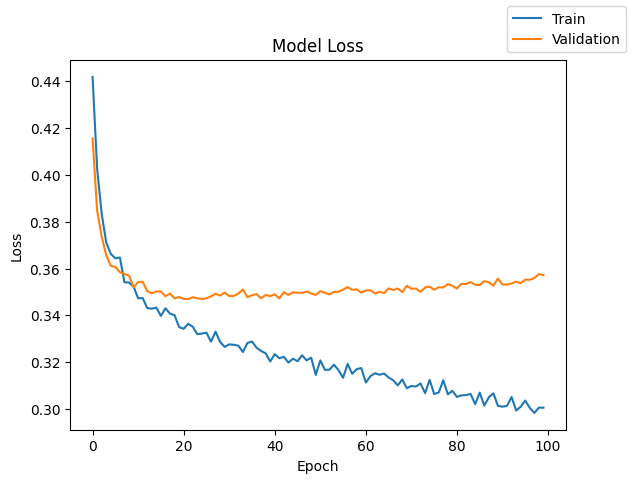

```python
plot(model_history, 'loss')
```

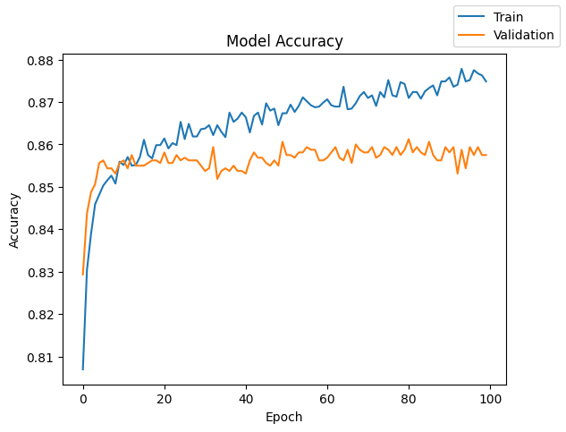

```python
plot(model_history, 'accuracy')
```

```python
model_3_train_perf = model_performance_classification(model, X_train, y_train)
model_3_train_perf
```

```
200/200 ━━━━━━━━━━━━━━━━━━━━ 0s 1ms/step
```

|  | Accuracy | Recall | Precision | F1 Score |
| --- | --- | --- | --- | --- |
| 0 | 0.885312 | 0.885312 | 0.880863 | 0.876101 |

```python
model_3_valid_perf = model_performance_classification(model, X_val, y_val)
model_3_valid_perf
```

```
50/50 ━━━━━━━━━━━━━━━━━━━━ 0s 1ms/step
```

|  | Accuracy | Recall | Precision | F1 Score |
| --- | --- | --- | --- | --- |
| 0 | 0.8575 | 0.8575 | 0.847249 | 0.844355 |

```python
results.loc[3] = ["NN with Adam and Dropout",2,'100','relu, tanh',100,32,model_history.history["loss"][-1],model_history.history["val_loss"][-1],model_history.history["accuracy"][-1],model_history.history["val_accuracy"][-1],round(end-start,2)]

results[0:4]
```

[output not shown]

### Neural Network with Balanced Data (by applying SMOTE) and SGD Optimizer

```python
print("Before OverSampling, counts of label '1': {}".format(sum(y_train==1)))
print("Before OverSampling, counts of label '0': {} \n".format(sum(y_train==0)))
```

```
Before OverSampling, counts of label '1': 1304
Before OverSampling, counts of label '0': 5096
```

```python
print("Before oversampling shape of X_train and y_train", X_train.shape, y_train.shape)
```

```
Before oversampling shape of X_train and y_train (6400, 11) (6400,)
```

```python
sm = SMOTE(random_state=42)
X_train_sm, y_train_sm = sm.fit_resample(X_train, y_train)
X_train_sm.shape, y_train_sm.shape
```

```
((10192, 11), (10192,))
```

```python
print("After Oversampling couts of label 1: {}".format(sum(y_train_sm==1)))
print("After Oversampling couts of label 0: {}".format(sum(y_train_sm==0)))
```

```
After Oversampling couts of label 1: 5096
After Oversampling couts of label 0: 5096
```

```python
model = Sequential()
model.add(Dense(100, activation='relu', input_dim=X_train.shape[1]))
model.add(Dense(100, activation='relu'))
model.add(Dense(1, activation='sigmoid'))

model.summary()
```

```
Model: "sequential_4"
```

```
┏━━━━━━━━━━━━━━━━━━━━━━━━━━━━━━━━━━━━━━┳━━━━━━━━━━━━━━━━━━━━━━━━━━━━━┳━━━━━━━━━━━━━━━━━┓
┃ Layer (type)                         ┃ Output Shape                ┃         Param # ┃
┡━━━━━━━━━━━━━━━━━━━━━━━━━━━━━━━━━━━━━━╇━━━━━━━━━━━━━━━━━━━━━━━━━━━━━╇━━━━━━━━━━━━━━━━━┩
│ dense_12 (Dense)                     │ (None, 100)                 │           1,200 │
├──────────────────────────────────────┼─────────────────────────────┼─────────────────┤
│ dense_13 (Dense)                     │ (None, 100)                 │          10,100 │
├──────────────────────────────────────┼─────────────────────────────┼─────────────────┤
│ dense_14 (Dense)                     │ (None, 1)                   │             101 │
└──────────────────────────────────────┴─────────────────────────────┴─────────────────┘
```

```
 Total params: 11,401 (44.54 KB)
```

```
 Trainable params: 11,401 (44.54 KB)
```

```
 Non-trainable params: 0 (0.00 B)
```

```python
model.compile(optimizer='sgd', loss='binary_crossentropy', metrics=['accuracy'])
```

```python
start = time.time()
model_history = model.fit(X_train_sm, y_train_sm, epochs=epochs, batch_size=batch_size, validation_data=(X_val, y_val))
end = time.time()
```

```
319/319 ━━━━━━━━━━━━━━━━━━━━ 1s 2ms/step - accuracy: 0.5401 - loss: 0.6842 - val_accuracy: 0.6800 - val_loss: 0.6359
319/319 ━━━━━━━━━━━━━━━━━━━━ 1s 2ms/step - accuracy: 0.6855 - loss: 0.6104 - val_accuracy: 0.7300 - val_loss: 0.5827
319/319 ━━━━━━━━━━━━━━━━━━━━ 1s 2ms/step - accuracy: 0.7133 - loss: 0.5757 - val_accuracy: 0.7400 - val_loss: 0.5557
319/319 ━━━━━━━━━━━━━━━━━━━━ 1s 2ms/step - accuracy: 0.7267 - loss: 0.5565 - val_accuracy: 0.7419 - val_loss: 0.5397
319/319 ━━━━━━━━━━━━━━━━━━━━ 1s 2ms/step - accuracy: 0.7368 - loss: 0.5421 - val_accuracy: 0.7431 - val_loss: 0.5269
319/319 ━━━━━━━━━━━━━━━━━━━━ 1s 2ms/step - accuracy: 0.7436 - loss: 0.5287 - val_accuracy: 0.7487 - val_loss: 0.5147
319/319 ━━━━━━━━━━━━━━━━━━━━ 1s 2ms/step - accuracy: 0.7513 - loss: 0.5152 - val_accuracy: 0.7550 - val_loss: 0.5026
319/319 ━━━━━━━━━━━━━━━━━━━━ 1s 2ms/step - accuracy: 0.7570 - loss: 0.5019 - val_accuracy: 0.7600 - val_loss: 0.4907
319/319 ━━━━━━━━━━━━━━━━━━━━ 1s 2ms/step - accuracy: 0.7622 - loss: 0.4896 - val_accuracy: 0.7694 - val_loss: 0.4801
319/319 ━━━━━━━━━━━━━━━━━━━━ 2s 3ms/step - accuracy: 0.7708 - loss: 0.4790 - val_accuracy: 0.7781 - val_loss: 0.4712
319/319 ━━━━━━━━━━━━━━━━━━━━ 1s 3ms/step - accuracy: 0.7766 - loss: 0.4701 - val_accuracy: 0.7806 - val_loss: 0.4641
319/319 ━━━━━━━━━━━━━━━━━━━━ 1s 3ms/step - accuracy: 0.7803 - loss: 0.4631 - val_accuracy: 0.7819 - val_loss: 0.4590
319/319 ━━━━━━━━━━━━━━━━━━━━ 1s 2ms/step - accuracy: 0.7829 - loss: 0.4578 - val_accuracy: 0.7819 - val_loss: 0.4552
319/319 ━━━━━━━━━━━━━━━━━━━━ 1s 2ms/step - accuracy: 0.7852 - loss: 0.4536 - val_accuracy: 0.7794 - val_loss: 0.4521
319/319 ━━━━━━━━━━━━━━━━━━━━ 1s 2ms/step - accuracy: 0.7885 - loss: 0.4504 - val_accuracy: 0.7837 - val_loss: 0.4497
319/319 ━━━━━━━━━━━━━━━━━━━━ 1s 2ms/step - accuracy: 0.7901 - loss: 0.4477 - val_accuracy: 0.7844 - val_loss: 0.4478
319/319 ━━━━━━━━━━━━━━━━━━━━ 1s 2ms/step - accuracy: 0.7930 - loss: 0.4453 - val_accuracy: 0.7862 - val_loss: 0.4462
319/319 ━━━━━━━━━━━━━━━━━━━━ 1s 2ms/step - accuracy: 0.7957 - loss: 0.4432 - val_accuracy: 0.7900 - val_loss: 0.4448
319/319 ━━━━━━━━━━━━━━━━━━━━ 1s 2ms/step - accuracy: 0.7969 - loss: 0.4413 - val_accuracy: 0.7894 - val_loss: 0.4434
319/319 ━━━━━━━━━━━━━━━━━━━━ 1s 2ms/step - accuracy: 0.7991 - loss: 0.4395 - val_accuracy: 0.7894 - val_loss: 0.4423
319/319 ━━━━━━━━━━━━━━━━━━━━ 1s 2ms/step - accuracy: 0.8009 - loss: 0.4378 - val_accuracy: 0.7894 - val_loss: 0.4413
319/319 ━━━━━━━━━━━━━━━━━━━━ 1s 2ms/step - accuracy: 0.8014 - loss: 0.4362 - val_accuracy: 0.7900 - val_loss: 0.4405
319/319 ━━━━━━━━━━━━━━━━━━━━ 1s 2ms/step - accuracy: 0.8016 - loss: 0.4347 - val_accuracy: 0.7894 - val_loss: 0.4397
319/319 ━━━━━━━━━━━━━━━━━━━━ 1s 2ms/step - accuracy: 0.8031 - loss: 0.4332 - val_accuracy: 0.7887 - val_loss: 0.4390
319/319 ━━━━━━━━━━━━━━━━━━━━ 1s 2ms/step - accuracy: 0.8030 - loss: 0.4317 - val_accuracy: 0.7894 - val_loss: 0.4382
319/319 ━━━━━━━━━━━━━━━━━━━━ 2s 3ms/step - accuracy: 0.8034 - loss: 0.4302 - val_accuracy: 0.7906 - val_loss: 0.4375
319/319 ━━━━━━━━━━━━━━━━━━━━ 1s 3ms/step - accuracy: 0.8040 - loss: 0.4287 - val_accuracy: 0.7906 - val_loss: 0.4367
319/319 ━━━━━━━━━━━━━━━━━━━━ 1s 3ms/step - accuracy: 0.8040 - loss: 0.4272 - val_accuracy: 0.7906 - val_loss: 0.4359
319/319 ━━━━━━━━━━━━━━━━━━━━ 1s 2ms/step - accuracy: 0.8045 - loss: 0.4257 - val_accuracy: 0.7919 - val_loss: 0.4350
319/319 ━━━━━━━━━━━━━━━━━━━━ 1s 2ms/step - accuracy: 0.8044 - loss: 0.4243 - val_accuracy: 0.7931 - val_loss: 0.4344
319/319 ━━━━━━━━━━━━━━━━━━━━ 1s 2ms/step - accuracy: 0.8046 - loss: 0.4229 - val_accuracy: 0.7931 - val_loss: 0.4337
319/319 ━━━━━━━━━━━━━━━━━━━━ 1s 2ms/step - accuracy: 0.8048 - loss: 0.4214 - val_accuracy: 0.7919 - val_loss: 0.4330
319/319 ━━━━━━━━━━━━━━━━━━━━ 1s 2ms/step - accuracy: 0.8052 - loss: 0.4200 - val_accuracy: 0.7912 - val_loss: 0.4322
319/319 ━━━━━━━━━━━━━━━━━━━━ 1s 2ms/step - accuracy: 0.8057 - loss: 0.4185 - val_accuracy: 0.7919 - val_loss: 0.4315
319/319 ━━━━━━━━━━━━━━━━━━━━ 1s 2ms/step - accuracy: 0.8064 - loss: 0.4170 - val_accuracy: 0.7925 - val_loss: 0.4307
319/319 ━━━━━━━━━━━━━━━━━━━━ 1s 2ms/step - accuracy: 0.8074 - loss: 0.4155 - val_accuracy: 0.7925 - val_loss: 0.4302
319/319 ━━━━━━━━━━━━━━━━━━━━ 1s 2ms/step - accuracy: 0.8076 - loss: 0.4140 - val_accuracy: 0.7956 - val_loss: 0.4296
319/319 ━━━━━━━━━━━━━━━━━━━━ 1s 2ms/step - accuracy: 0.8092 - loss: 0.4125 - val_accuracy: 0.7975 - val_loss: 0.4287
319/319 ━━━━━━━━━━━━━━━━━━━━ 1s 2ms/step - accuracy: 0.8106 - loss: 0.4110 - val_accuracy: 0.7987 - val_loss: 0.4282
319/319 ━━━━━━━━━━━━━━━━━━━━ 1s 2ms/step - accuracy: 0.8114 - loss: 0.4095 - val_accuracy: 0.7981 - val_loss: 0.4276
```

[output cut: 45 more lines]

```
319/319 ━━━━━━━━━━━━━━━━━━━━ 1s 2ms/step - accuracy: 0.8560 - loss: 0.3294 - val_accuracy: 0.8175 - val_loss: 0.4163
319/319 ━━━━━━━━━━━━━━━━━━━━ 1s 2ms/step - accuracy: 0.8574 - loss: 0.3275 - val_accuracy: 0.8175 - val_loss: 0.4163
319/319 ━━━━━━━━━━━━━━━━━━━━ 1s 2ms/step - accuracy: 0.8581 - loss: 0.3256 - val_accuracy: 0.8163 - val_loss: 0.4164
319/319 ━━━━━━━━━━━━━━━━━━━━ 1s 2ms/step - accuracy: 0.8596 - loss: 0.3238 - val_accuracy: 0.8169 - val_loss: 0.4163
319/319 ━━━━━━━━━━━━━━━━━━━━ 1s 2ms/step - accuracy: 0.8617 - loss: 0.3219 - val_accuracy: 0.8175 - val_loss: 0.4167
319/319 ━━━━━━━━━━━━━━━━━━━━ 2s 3ms/step - accuracy: 0.8617 - loss: 0.3201 - val_accuracy: 0.8188 - val_loss: 0.4168
319/319 ━━━━━━━━━━━━━━━━━━━━ 1s 3ms/step - accuracy: 0.8629 - loss: 0.3183 - val_accuracy: 0.8181 - val_loss: 0.4172
319/319 ━━━━━━━━━━━━━━━━━━━━ 1s 3ms/step - accuracy: 0.8640 - loss: 0.3165 - val_accuracy: 0.8194 - val_loss: 0.4172
319/319 ━━━━━━━━━━━━━━━━━━━━ 1s 2ms/step - accuracy: 0.8659 - loss: 0.3146 - val_accuracy: 0.8206 - val_loss: 0.4175
319/319 ━━━━━━━━━━━━━━━━━━━━ 1s 2ms/step - accuracy: 0.8677 - loss: 0.3129 - val_accuracy: 0.8200 - val_loss: 0.4181
319/319 ━━━━━━━━━━━━━━━━━━━━ 1s 2ms/step - accuracy: 0.8687 - loss: 0.3111 - val_accuracy: 0.8194 - val_loss: 0.4185
319/319 ━━━━━━━━━━━━━━━━━━━━ 1s 2ms/step - accuracy: 0.8686 - loss: 0.3092 - val_accuracy: 0.8200 - val_loss: 0.4192
319/319 ━━━━━━━━━━━━━━━━━━━━ 1s 2ms/step - accuracy: 0.8694 - loss: 0.3074 - val_accuracy: 0.8194 - val_loss: 0.4198
319/319 ━━━━━━━━━━━━━━━━━━━━ 1s 2ms/step - accuracy: 0.8715 - loss: 0.3057 - val_accuracy: 0.8175 - val_loss: 0.4205
319/319 ━━━━━━━━━━━━━━━━━━━━ 1s 2ms/step - accuracy: 0.8721 - loss: 0.3039 - val_accuracy: 0.8181 - val_loss: 0.4213
```

```python
print("Time taken in seconds", end-start)
```

```
Time taken in seconds 107.32571053504944
```

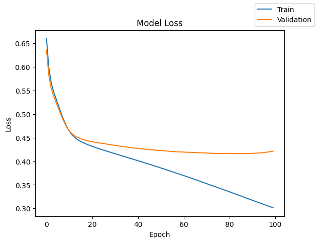

```python
plot(model_history, 'loss')
```

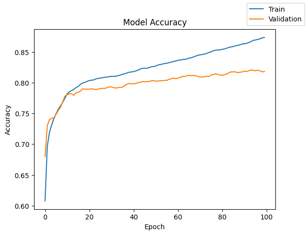

```python
plot(model_history, 'accuracy')
```

```python
model_4_train_perf = model_performance_classification(model, X_train_sm, y_train_sm)
model_4_train_perf
```

```
319/319 ━━━━━━━━━━━━━━━━━━━━ 1s 1ms/step
```

|  | Accuracy | Recall | Precision | F1 Score |
| --- | --- | --- | --- | --- |
| 0 | 0.875883 | 0.875883 | 0.876124 | 0.875863 |

```python
model_4_valid_perf = model_performance_classification(model, X_val, y_val)
model_4_valid_perf
```

```
50/50 ━━━━━━━━━━━━━━━━━━━━ 0s 1ms/step
```

|  | Accuracy | Recall | Precision | F1 Score |
| --- | --- | --- | --- | --- |
| 0 | 0.818125 | 0.818125 | 0.831849 | 0.823675 |

```python
results.loc[4] = ["NN with SGD and SMOTE",2,'100','relu',100,32,model_history.history["loss"][-1],model_history.history["val_loss"][-1],model_history.history["accuracy"][-1],model_history.history["val_accuracy"][-1],round(end-start,2)]

results[0:5]
```

[output not shown]